# DSI Project - Diabetes data processing and prediction

#### Name: Stav Osherov

## Introduction

The dataset presented in the project is part of a wider datasest from the National Institute of Diabetes and Digestive and Kidney Diseases in Maryland, USA.  
In the dataset there are medical samples of Pima women.

**What is Pima?** Pima is a Native American heritage that nowadays are primarily on reservations in Arizona and their descendants numbered some 11,000 (from Encyclopedia Britannica).

**The objective** of the project is to diagnostically predict if a female patient has diabetes based on diagnostic measurements included in the dataset.

#### Diabetes background (from Ichilov Hospital)

Diabetes is metabolic disease characterized by high concentration of sugar (glucose) in blood and urine.  
The main problem of diabetes is relatively or absolute absence of the insulin hormone. Insulin created in the pancreatic gland and secrete from it to the bloodstream in case of increasement in sugar level. The Insulin acts like a key to let the blood sugar into the body’s cells for use as energy, therefore, for diabetes patients there is no suitable response of Insulin release when sugar level rises in the blood.  
There are 3 types of diabetes: Type 1 diabetes, Type 2 diabetes and Gestational diabetes.

*Type 1 diabetes:* Also known as juvenile diabetes, appears mostly at childhood and caused by lack of insulin as a result of destruction of the cells in the pancreas responsible for insulin secretion from autoimmune factors, hereditary predisposition, milk allergy and etc. The treatment of this diabetes requires receiving insulin externally.

*Type 2 diabetes:* Also known as adult-onset diabetes, develops in older age (usually after 40) and more common among women, This diabetes results from a high resistance of the tissues to the effect of insulin. The prevalence of this diabetes increases in cases of over-weight and it has a significant hereditary component. The treatment includes changes in lifestyle like exercise, proper nutrition and taking medications, sometimes requires receiving insulin.

*Gestational diabetes:* Develops during pregnancy and lessened after delivery, this is a relatively common condition. It is also known that women who developed diabetes during pregnancy are at increased risk of developing type 2 diabetes later in life, especially in cases where there are additional risk factors for the emergence of type 2 diabetes.

**Research questions** that will be asked:

- Which medical data influence the prediction?
- Are there items of data that influence other?

**Initial hypothesis**:

- Based on the diabetes background, low values of insulin will influence the prediction.
- Based on the diabetes background, insulin level depends on suger level in the blood (aka. glucose).

The project will try to answer the questions by the use of packages: `NumPy`, `Pandas`, `Matplotlib`, `Seaborn`, `SciPy`, `Scikit-Learn`

### Import packages

```python
import numpy as np
import pandas as pd
import matplotlib.pyplot as plt
%matplotlib inline
import seaborn as sns
from scipy import stats as st
from sklearn.neighbors import KNeighborsClassifier
from sklearn.linear_model import LinearRegression
from sklearn.linear_model import LogisticRegression
from sklearn.ensemble import RandomForestClassifier
```

### Upload dataset

Creating a DataFrame called `diabetes` from external .csv file that is already uploaded

```python
diabetes=pd.read_csv('diabetes.csv')
```

First, let's take a look of the dataset:

```python
diabetes.head()
```

|  | Pregnancies | Glucose | BloodPressure | SkinThickness | Insulin | BMI | DiabetesPedigreeFunction | Age | Outcome |
| --- | --- | --- | --- | --- | --- | --- | --- | --- | --- |
| 0 | 6 | 148 | 72 | 35 | 0 | 33.6 | 0.627 | 50 | 1 |
| 1 | 1 | 85 | 66 | 29 | 0 | 26.6 | 0.351 | 31 | 0 |
| 2 | 8 | 183 | 64 | 0 | 0 | 23.3 | 0.672 | 32 | 1 |
| 3 | 1 | 89 | 66 | 23 | 94 | 28.1 | 0.167 | 21 | 0 |
| 4 | 0 | 137 | 40 | 35 | 168 | 43.1 | 2.288 | 33 | 1 |

## Technical details & EDA

To understand and clarify the dataset.  
First, the size of the the dataset:

```python
diabetes.shape
```

```
(768, 9)
```

```python
diabetes.columns
```

```
Index(['Pregnancies', 'Glucose', 'BloodPressure', 'SkinThickness', 'Insulin',
       'BMI', 'DiabetesPedigreeFunction', 'Age', 'Outcome'],
      dtype='object')
```

`diabetes` dataset variables description:

- `Pregnancies`: Number of pregnancies.
- `Glucose`: Plasma glucose concentration a 2 hours in an oral glucose tolerance test.
- `BloodPressure`: Diastolic blood pressure (mm Hg).
- `SkinThickness`: Triceps skin fold thickness (mm).
- `Insulin`: 2-Hour serum insulin (mu U/ml).
- `BMI`: Body mass index (weight in kg/(height in m)^2).
- `DiabetesPedigreeFunction`: Function which scores likelihood of diabetes based on family history.
- `Age`: Age of the person (years).
- `Outcome`: Target variable, indicates if the patient has a diabetes or not.

Variables type:

```python
diabetes.info()
```

```
<class 'pandas.core.frame.DataFrame'>
RangeIndex: 768 entries, 0 to 767
Data columns (total 9 columns):
 #   Column                    Non-Null Count  Dtype
---  ------                    --------------  -----
 0   Pregnancies               768 non-null    int64
 1   Glucose                   768 non-null    int64
 2   BloodPressure             768 non-null    int64
 3   SkinThickness             768 non-null    int64
 4   Insulin                   768 non-null    int64
 5   BMI                       768 non-null    float64
 6   DiabetesPedigreeFunction  768 non-null    float64
 7   Age                       768 non-null    int64
 8   Outcome                   768 non-null    int64
dtypes: float64(2), int64(7)
memory usage: 54.1 KB
```

Most variables in `diabetes` are **numerical variables** with the following sub-categories:

| Discrete | Continuous |
| --- | --- |
| Pregnancies | BMI |
| Glucose | DiabetesPedigreeFunction |
| BloodPressure |  |
| SkinThickness |  |
| Insulin |  |
| Age |  |

`Outcome` is a binary variable where 0 - not diabetic and 1 - diabetic, therefore labeled as **nominal categorical variable**.

From info, for every variable there are 768 non-null values, i.e. the dataset doesn't consist any null values.  
Examination with `isnull()`:

```python
diabetes.isnull().sum()
```

```
Pregnancies                 0
Glucose                     0
BloodPressure               0
SkinThickness               0
Insulin                     0
BMI                         0
DiabetesPedigreeFunction    0
Age                         0
Outcome                     0
dtype: int64
```

Every variable has 0 null values, therefore same conclusion, the dataset doesn't consist any null values and moreover, the dataset dataset doesn't consist any null samples (rows).

## Data transformation

Detecting exceptional values, cleaning and wrangling data.  
First, let's check for duplication:

```python
diabetes_dup=diabetes.duplicated()
print((diabetes[(diabetes_dup)==True]).index)
```

```
Int64Index([], dtype='int64')
```

`diabetes` dataset doesn't have sample duplication

```python
diabetes.describe().T
```

|  | count | mean | std | min | 25% | 50% | 75% | max |
| --- | --- | --- | --- | --- | --- | --- | --- | --- |
| Pregnancies | 768.0 | 3.845052 | 3.369578 | 0.000 | 1.00000 | 3.0000 | 6.00000 | 17.00 |
| Glucose | 768.0 | 120.894531 | 31.972618 | 0.000 | 99.00000 | 117.0000 | 140.25000 | 199.00 |
| BloodPressure | 768.0 | 69.105469 | 19.355807 | 0.000 | 62.00000 | 72.0000 | 80.00000 | 122.00 |
| SkinThickness | 768.0 | 20.536458 | 15.952218 | 0.000 | 0.00000 | 23.0000 | 32.00000 | 99.00 |
| Insulin | 768.0 | 79.799479 | 115.244002 | 0.000 | 0.00000 | 30.5000 | 127.25000 | 846.00 |
| BMI | 768.0 | 31.992578 | 7.884160 | 0.000 | 27.30000 | 32.0000 | 36.60000 | 67.10 |
| DiabetesPedigreeFunction | 768.0 | 0.471876 | 0.331329 | 0.078 | 0.24375 | 0.3725 | 0.62625 | 2.42 |
| Age | 768.0 | 33.240885 | 11.760232 | 21.000 | 24.00000 | 29.0000 | 41.00000 | 81.00 |
| Outcome | 768.0 | 0.348958 | 0.476951 | 0.000 | 0.00000 | 0.0000 | 1.00000 | 1.00 |

From first look, it seem there is the exceptional value `min = 0` in variables: `Glucose`, `BloodPressure`, `SkinThickness`, `Insulin` and `BMI`.

`diabetes` dataset doesn't have many samples, therefore let's view two options for handling those missing values:

1. Remove rows with exceptional values and complete them by **correlation and binning**- After removing excessive rows there can be set off more pointed value completion using correlation to other informative variables and thin binning.
2. Complete all missing values of all rows by **distribution**- View the distribution of variable including the exceptional values and complete according to the distribution by mean, median or other statistical value.

Before missing values, let's view outliers using `boxplot`:

### Detecte outliers

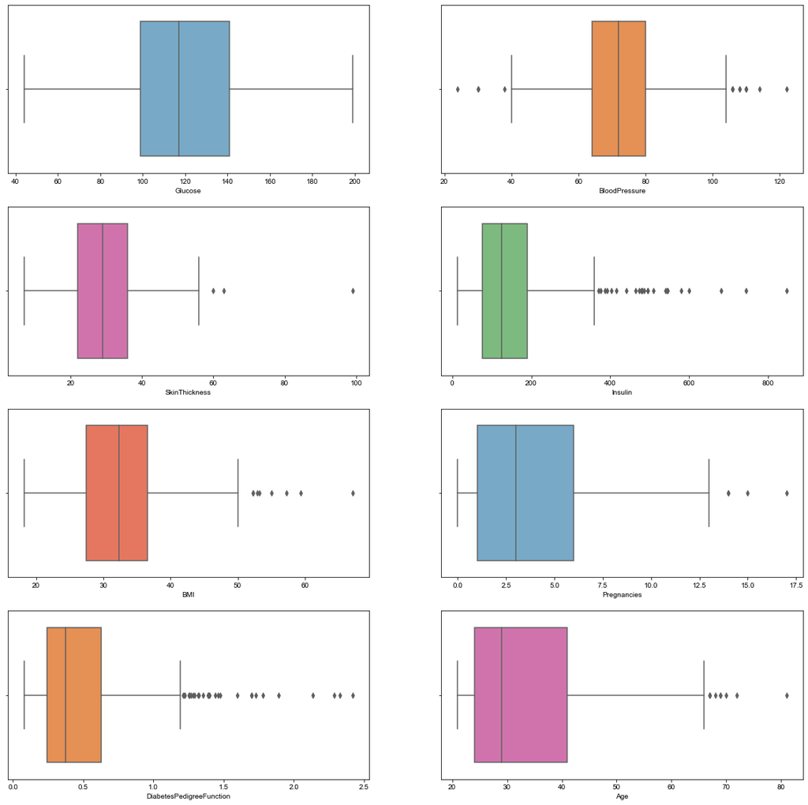

```python
# First, replace 0's with NaN for convenience
diabetes[['Glucose','BloodPressure','SkinThickness','Insulin','BMI']] = diabetes[['Glucose','BloodPressure','SkinThickness',
                                                                                  'Insulin','BMI']].replace(0,np.NaN)

fig, axes = plt.subplots(4, 2, figsize=(20,20))

sns.boxplot(ax=axes[0,0], data=diabetes, x='Glucose', hue='Outcome', palette= "Blues")
sns.boxplot(ax=axes[0,1], data=diabetes, x='BloodPressure', hue='Outcome', palette= "Oranges")
sns.boxplot(ax=axes[1,0], data=diabetes, x='SkinThickness', hue='Outcome', palette= "PuRd")
sns.boxplot(ax=axes[1,1], data=diabetes, x='Insulin', hue='Outcome', palette= "Greens")
sns.boxplot(ax=axes[2,0], data=diabetes, x='BMI', hue='Outcome', palette= "Reds")
sns.boxplot(ax=axes[2,1], data=diabetes, x='Pregnancies', hue='Outcome', palette= "Blues")
sns.boxplot(ax=axes[3,0], data=diabetes, x='DiabetesPedigreeFunction', hue='Outcome', palette= "Oranges")
sns.boxplot(ax=axes[3,1], data=diabetes, x='Age', hue='Outcome', palette= "PuRd")
sns.set_theme()
plt.show()
```

In`boxplot` all the dots are outliers.  
Let's use **IQR approach** to replace outliers with null values- The IQR (interquartile range) approach measure the scattering of values in the variable, the interquartile range is a range in which half of the values are found.

Function to apply IQR:

```python
def iqr_outliers(var):
    temp=var.dropna()
    q25= temp.quantile(0.25) # 25-percentile
    q75= temp.quantile(0.75) # 75-percentile
    interq_rng= q75-q25

    lower_bound= q25-(1.5*interq_rng)
    upper_bound= q75+(1.5*interq_rng)

    return lower_bound, upper_bound
```

Let's apply IQR on variables that already have exceptional value : `SkinThickness`, `Insulin` and `BMI`.

At the IQR approach the values that are out of the interquartile range become null value, therefore it's best not to apply IQR on informative variables (without exceptional values) like `DiabetesPedigreeFunction`.

```python
# IQR application
# SkinThickness outliers remove
st_lb, st_ub= iqr_outliers(diabetes['SkinThickness'])
diabetes['SkinThickness'] = np.where((diabetes['SkinThickness']<st_lb) | (diabetes['SkinThickness']>st_ub), np.NaN,
                                     diabetes['SkinThickness'])

# Insulin outliers remove
ins_lb, ins_ub= iqr_outliers(diabetes['Insulin'])
diabetes['Insulin'] = np.where((diabetes['Insulin']<ins_lb) | (diabetes['Insulin']>ins_ub), np.NaN, diabetes['Insulin'])

# BMI outliers remove
bmi_lb, bmi_ub= iqr_outliers(diabetes['BMI'])
diabetes['BMI'] = np.where((diabetes['BMI']<bmi_lb) | (diabetes['BMI']>bmi_ub), np.NaN, diabetes['BMI'])
```

Let's view outliers after IQR:

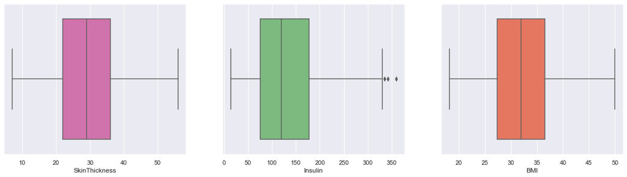

```python
fig, axes = plt.subplots(1, 3, figsize=(20,5))

sns.boxplot(ax=axes[0], data=diabetes, x='SkinThickness', palette= "PuRd")
sns.boxplot(ax=axes[1], data=diabetes, x='Insulin', palette= "Greens")
sns.boxplot(ax=axes[2], data=diabetes, x='BMI', palette= "Reds")

sns.set_theme()
plt.show()
```

Now, Let's deal with missing values:

### 1. Removing and correlation & binning

#### Remove uninformative rows

```python
diabetes['Outcome'].value_counts()
```

```
0    500
1    268
Name: Outcome, dtype: int64
```

Before removing rows, it can be noticed there are 500 non-diabetic patient and 268 diabetic patients, i.e. the amount of non-diabetic samples is double the amount of diabetic samples.

Let's remove rows with 4 or more exceptional values:

```python
diab_without_rows= diabetes.copy()

# First, replace 0's with NaN for convenience
diab_without_rows[['Glucose','BloodPressure','SkinThickness','Insulin','BMI']] = diab_without_rows[['Glucose','BloodPressure',
                                                                                                    'SkinThickness','Insulin',
                                                                                                    'BMI']].replace(0,np.NaN)

# Removing rows
diab_without_rows.dropna(thresh=6, inplace= True)

diab_without_rows['Outcome'].value_counts()
```

```
0    494
1    266
Name: Outcome, dtype: int64
```

After removing rows there are 494 non-diabetes patient and 266 diabetes patients, there were 8 uninformative rows.  
That's not balance the ratio between the samples but the lost at the diabetes samples is small, therefore it's fine to continue with the method:

#### Correlation and binning

First, let's check the variable with the least missing values:

```python
# First, replace NaN with 0 for plot
diab_1= diab_without_rows.copy()
diab_1[['Glucose','BloodPressure','SkinThickness','Insulin','BMI']] = diab_1[['Glucose','BloodPressure','SkinThickness',
                                                                              'Insulin','BMI']].replace(np.NaN,0)

missing_val= ['Glucose','BloodPressure','SkinThickness','Insulin','BMI']
print((diab_1[missing_val]==0).sum())
```

```
Glucose            5
BloodPressure     27
SkinThickness    222
Insulin          390
BMI               11
dtype: int64
```

`Glucose` is the variable with the least of missing values, therefore let's check its relation among the variables without the missing value (`Age`, `DiabetesPedigreeFunction` and `Pregnancies`):

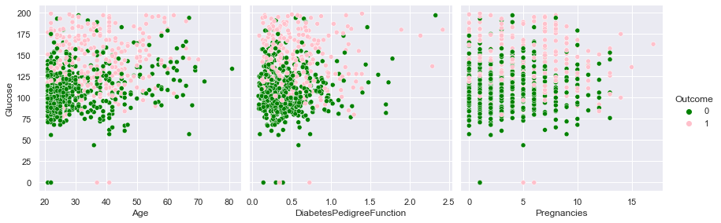

```python
plt.figure(figsize= (10,10))

sns.pairplot(data=diab_1, hue='Outcome',x_vars=['Age', 'DiabetesPedigreeFunction', 'Pregnancies'], y_vars='Glucose',
            height=4, aspect=1, palette={0:"green",1:"pink"})
sns.set_theme()
plt.show()
```

It seems that in the relation of `Glucose` with `DiabetesPedigreeFunction` and `Glucose` with `Age` the group of diabetes patients is collected and non-diabetes patients is collected, let's check correlation:

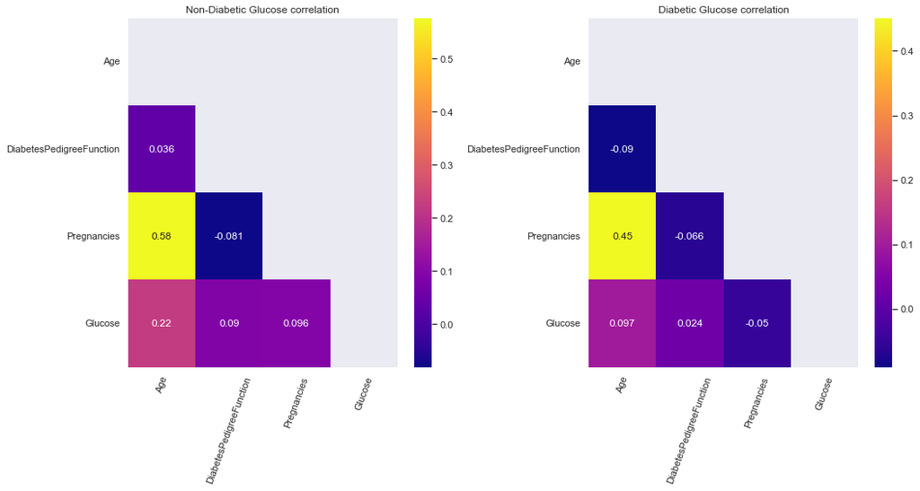

```python
non_diabetic_patient= diab_1[(diab_1['Outcome']==0)]
diabetic_patient= diab_1[(diab_1['Outcome']==1)]

fig, axes = plt.subplots(1, 2, figsize=(15, 8))

# Non-diabetic Glucose correlation
compar_data_non_diab= non_diabetic_patient[['Age', 'DiabetesPedigreeFunction','Pregnancies','Glucose']]
triang_non_diab = np.triu(np.ones_like(compar_data_non_diab.corr()))
sns.heatmap(compar_data_non_diab.corr(), mask= triang_non_diab, annot=True ,cmap = 'plasma', ax=axes[0])
axes[0].tick_params(axis='x', rotation=70)
axes[0].tick_params(axis='y', rotation=0)
axes[0].title.set_text("Non-Diabetic Glucose correlation")

# Diabetic Glucose correlation
compar_data_diab= diabetic_patient[['Age', 'DiabetesPedigreeFunction','Pregnancies','Glucose']]
triang_diab = np.triu(np.ones_like(compar_data_diab.corr()))
sns.heatmap(compar_data_diab.corr(), mask= triang_diab, annot=True ,cmap = 'plasma', ax=axes[1])
axes[1].tick_params(axis='x', rotation=70)
axes[1].tick_params(axis='y', rotation=0)
axes[1].title.set_text("Diabetic Glucose correlation")

fig.tight_layout()
sns.set_theme()
plt.show()
```

The correlation of `Glucose` and `Age` is higher for both diabetic and non-diabetic patients, meaning more linearly related.  
Let's view the linear relation:

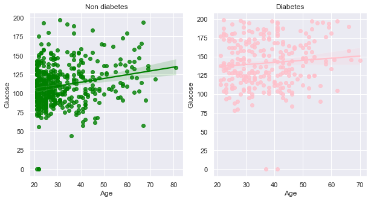

```python
non_diabetic_patient= diab_1[(diab_1['Outcome']==0)]
diabetic_patient= diab_1[(diab_1['Outcome']==1)]

fig, axes = plt.subplots(1, 2, figsize=(10, 5))
sns.regplot(ax=axes[0], data=non_diabetic_patient, x='Age', y='Glucose', color="green")
axes[0].title.set_text("Non diabetes")
sns.regplot(ax=axes[1], data=diabetic_patient, x='Age', y='Glucose',  color="pink")
axes[1].title.set_text("Diabetes")

sns.set_theme()
plt.show()
```

Let's create `Age` bins to complete `Glucose` values: "young-adult" ages 20-39, "adults" ages 40-59 and "senior" ages 60-81

```python
bins_age_1 = [20, 39, 59, 81]
cats_age_1 = pd.cut(diab_1['Age'], bins_age_1, labels=["young-adult","adults", "senior"])
diab_1['AgeCats']= cats_age_1

# Replace 0's with NaN for convenience
diab_1[['Glucose','BloodPressure','SkinThickness','Insulin','BMI']] = diab_1[['Glucose','BloodPressure','SkinThickness',
                                                                              'Insulin','BMI']].replace(0,np.NaN)

# Change NaN values of Glucose by "young-adult"
young_adult_cat= diab_1[diab_1['AgeCats']=="young-adult"]
# Non-diabetic
young_adult_non_diab= young_adult_cat[young_adult_cat['Outcome']==0]
young_adult_non_diab_val=int(young_adult_non_diab['Glucose'].mean(skipna=True))
diab_1['Glucose'] = np.where((diab_1['Glucose'].isnull()) & (diab_1['AgeCats'] == "young-adult") & (diab_1['Outcome'] == 0),
                             young_adult_non_diab_val, diab_1['Glucose'])
# Diabetic
young_adult_diab= young_adult_cat[young_adult_cat['Outcome']==1]
young_adult_diab_val=int(young_adult_diab['Glucose'].mean(skipna=True))
diab_1['Glucose'] = np.where((diab_1['Glucose'].isnull()) & (diab_1['AgeCats'] == "young-adult") & (diab_1['Outcome'] == 1),
                             young_adult_diab_val, diab_1['Glucose'])

# Change NaN values of Glucose by "adults" score
adult_cat= diab_1[diab_1['AgeCats']=="adults"]
# Non-diabetic
adult_non_diab= adult_cat[adult_cat['Outcome']==0]
adult_non_diab_val=int(adult_non_diab['Glucose'].mean(skipna=True))
diab_1['Glucose'] = np.where((diab_1['Glucose'].isnull()) & (diab_1['AgeCats'] == "adults") & (diab_1['Outcome'] == 0),
                             adult_non_diab_val, diab_1['Glucose'])
# Diabetic
adult_diab= adult_cat[adult_cat['Outcome']==1]
adult_diab_val=int(adult_diab['Glucose'].mean(skipna=True))
diab_1['Glucose'] = np.where((diab_1['Glucose'].isnull()) & (diab_1['AgeCats'] == "adults") & (diab_1['Outcome'] == 1),
                             adult_diab_val, diab_1['Glucose'])

# Change NaN values of Glucose by "senior" score
senior_cat= diab_1[diab_1['AgeCats']=="senior"]
# Non-diabetic
senior_non_diab= senior_cat[senior_cat['Outcome']==0]
senior_non_diab_val=int(senior_non_diab['Glucose'].mean(skipna=True))
diab_1['Glucose'] = np.where((diab_1['Glucose'].isnull()) & (diab_1['AgeCats'] == "senior") & (diab_1['Outcome'] == 0),
                             senior_non_diab_val, diab_1['Glucose'])
# Diabetic
senior_diab= senior_cat[senior_cat['Outcome']==1]
senior_diab_val=int(senior_diab['Glucose'].mean(skipna=True))
diab_1['Glucose'] = np.where((diab_1['Glucose'].isnull()) & (diab_1['AgeCats'] == "senior") & (diab_1['Outcome'] == 1),
                             senior_diab_val, diab_1['Glucose'])

print(diab_1[missing_val].isnull().sum())
```

```
Glucose            0
BloodPressure     27
SkinThickness    222
Insulin          390
BMI               11
dtype: int64
```

Missing values of `Glucose` handeled, next let's view `BMI` relation among the variables without the missing value:

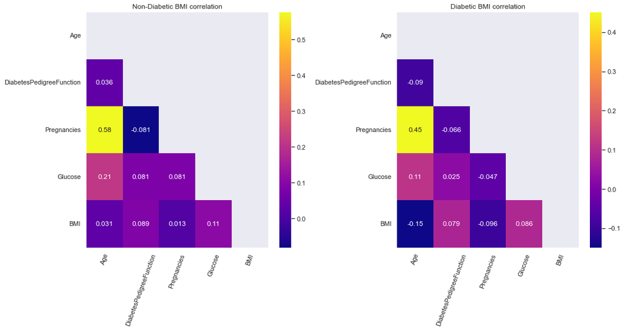

```python
non_diabetic_patient= diab_1[(diab_1['Outcome']==0)]
diabetic_patient= diab_1[(diab_1['Outcome']==1)]

fig, axes = plt.subplots(1, 2, figsize=(15, 8))

# Non-diabetic BMI correlation
compar_data_non_diab= non_diabetic_patient[['Age', 'DiabetesPedigreeFunction','Pregnancies','Glucose', 'BMI']]
triang_non_diab = np.triu(np.ones_like(compar_data_non_diab.corr()))
sns.heatmap(compar_data_non_diab.corr(), mask= triang_non_diab, annot=True ,cmap = 'plasma', ax=axes[0])
axes[0].tick_params(axis='x', rotation=70)
axes[0].tick_params(axis='y', rotation=0)
axes[0].title.set_text("Non-Diabetic BMI correlation")

# Diabetic BMI correlation
compar_data_diab= diabetic_patient[['Age', 'DiabetesPedigreeFunction','Pregnancies','Glucose', 'BMI']]
triang_diab = np.triu(np.ones_like(compar_data_diab.corr()))
sns.heatmap(compar_data_diab.corr(), mask= triang_diab, annot=True ,cmap = 'plasma', ax=axes[1])
axes[1].tick_params(axis='x', rotation=70)
axes[1].tick_params(axis='y', rotation=0)
axes[1].title.set_text("Diabetic BMI correlation")

fig.tight_layout()
sns.set_theme()
plt.show()
```

The correlation of `BMI` and `Glucose` is higher for both diabetic and non-diabetic patients.  
Let's check `Glucose` min and max:

```python
print("Glucose min:", diab_1['Glucose'].min())
print("Glucose max:", diab_1['Glucose'].max())
```

```
Glucose min: 44.0
Glucose max: 199.0
```

Let's creat `Glucose` bins: "beneath norm" 40-70, "norm" 70-100, "above norm" 100-130, "anomalous" 130-165 and "risk" 165-200

```python
bins_gluc_1 = [40, 69, 99, 129 ,164, 200]
cats_gluc_1 = pd.cut(diab_1['Glucose'], bins_gluc_1, labels=["beneath norm", "norm", "above norm", "anomalous", "risk"])
diab_1['GlucoseCats']= cats_gluc_1

# Change NaN values of BMI by "beneath norm"
beneath_norm_cat= diab_1[diab_1['GlucoseCats']=="beneath norm"]
# Non-diabetic
beneath_norm_non_diab= beneath_norm_cat[beneath_norm_cat['Outcome']==0]
beneath_norm_non_diab_val=beneath_norm_non_diab['BMI'].mean(skipna=True)
diab_1['BMI'] = np.where((diab_1['BMI'].isnull()) & (diab_1['GlucoseCats'] == "beneath norm") & (diab_1['Outcome'] == 0),
                         beneath_norm_non_diab_val, diab_1['BMI'])
# Diabetic - There are no beneath norm diabetic
#beneath_norm_diab= beneath_norm_cat[beneath_norm_cat['Outcome']==1]
#beneath_norm_diab_val=int(beneath_norm_diab['BMI'].mean(skipna=True))
#diab_1['BMI'] = np.where((diab_1['BMI'].isnull()) & (diab_1['GlucoseCats'] == "beneath norm") & (diab_1['Outcome'] == 1),
#                         beneath_norm_diab_val, diab_1['BMI'])

# Change NaN values of BMI by "norm" score
norm_cat= diab_1[diab_1['GlucoseCats']=="norm"]
# Non-diabetic
norm_non_diab= norm_cat[norm_cat['Outcome']==0]
norm_non_diab_val=norm_non_diab['BMI'].mean(skipna=True)
diab_1['BMI'] = np.where((diab_1['BMI'].isnull()) & (diab_1['GlucoseCats'] == "norm") & (diab_1['Outcome'] == 0),
                         norm_non_diab_val, diab_1['BMI'])
# Diabetic
norm_diab= norm_cat[norm_cat['Outcome']==1]
norm_diab_val=norm_diab['BMI'].mean(skipna=True)
diab_1['BMI'] = np.where((diab_1['BMI'].isnull()) & (diab_1['GlucoseCats'] == "norm") & (diab_1['Outcome'] == 1),
                         norm_diab_val, diab_1['BMI'])

# Change NaN values of BMI by "above norm" score
above_norm_cat= diab_1[diab_1['GlucoseCats']=="above norm"]
# Non-diabetic
above_norm_non_diab= above_norm_cat[above_norm_cat['Outcome']==0]
above_norm_non_diab_val=above_norm_non_diab['BMI'].mean(skipna=True)
diab_1['BMI'] = np.where((diab_1['BMI'].isnull()) & (diab_1['GlucoseCats'] == "above norm") & (diab_1['Outcome'] == 0),
                         above_norm_non_diab_val, diab_1['BMI'])
# Diabetic
above_norm_diab= above_norm_cat[above_norm_cat['Outcome']==1]
above_norm_diab_val=above_norm_diab['BMI'].mean(skipna=True)
diab_1['BMI'] = np.where((diab_1['BMI'].isnull()) & (diab_1['GlucoseCats'] == "above norm") & (diab_1['Outcome'] == 1),
                         above_norm_diab_val, diab_1['BMI'])

# Change NaN values of BMI by "anomalous" score
anomalous_cat= diab_1[diab_1['GlucoseCats']=="anomalous"]
# Non-diabetic
anomalous_non_diab= anomalous_cat[anomalous_cat['Outcome']==0]
anomalous_non_diab_val=anomalous_non_diab['BMI'].mean(skipna=True)
diab_1['BMI'] = np.where((diab_1['BMI'].isnull()) & (diab_1['GlucoseCats'] == "anomalous") & (diab_1['Outcome'] == 0),
                         anomalous_non_diab_val, diab_1['BMI'])
# Diabetic
anomalous_diab= anomalous_cat[anomalous_cat['Outcome']==1]
anomalous_diab_val=anomalous_diab['BMI'].mean(skipna=True)
diab_1['BMI'] = np.where((diab_1['BMI'].isnull()) & (diab_1['GlucoseCats'] == "anomalous") & (diab_1['Outcome'] == 1),
                         anomalous_diab_val, diab_1['BMI'])

# Change NaN values of BMI by "risk" score
risk_cat= diab_1[diab_1['GlucoseCats']=="risk"]
# Non-diabetic
risk_non_diab= risk_cat[risk_cat['Outcome']==0]
risk_non_diab_val=risk_non_diab['BMI'].mean(skipna=True)
diab_1['BMI'] = np.where((diab_1['BMI'].isnull()) & (diab_1['GlucoseCats'] == "risk") & (diab_1['Outcome'] == 0),
                         risk_non_diab_val, diab_1['BMI'])
# Diabetic
risk_diab= risk_cat[risk_cat['Outcome']==1]
risk_diab_val=risk_diab['BMI'].mean(skipna=True)
diab_1['BMI'] = np.where((diab_1['BMI'].isnull()) & (diab_1['GlucoseCats'] == "risk") & (diab_1['Outcome'] == 1),
                         risk_diab_val, diab_1['BMI'])

print(diab_1[missing_val].isnull().sum())
```

```
Glucose            0
BloodPressure     27
SkinThickness    222
Insulin          390
BMI                0
dtype: int64
```

Missing values of `BMI` handeled, next let's view `BloodPressure` relation among the variables without the missing value:

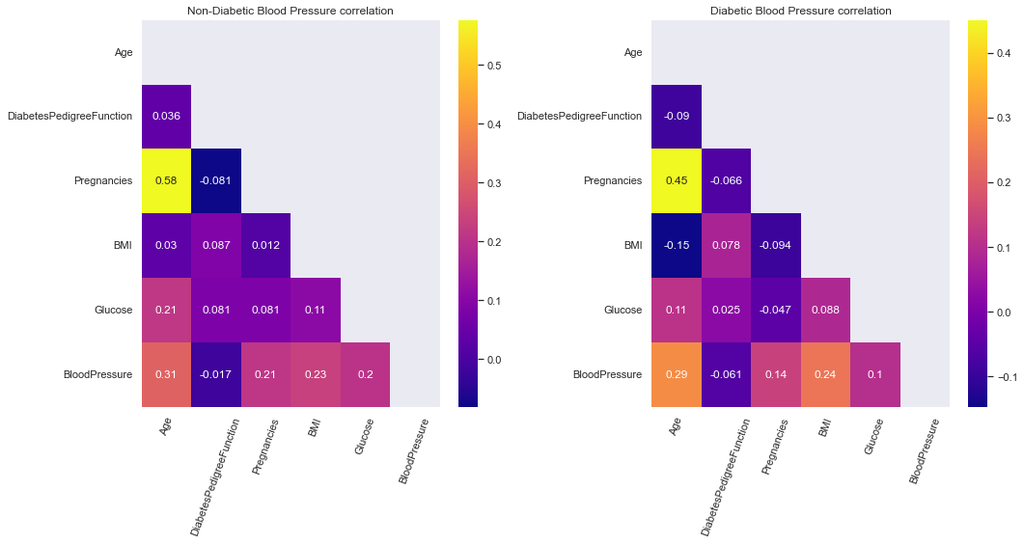

```python
non_diabetic_patient= diab_1[(diab_1['Outcome']==0)]
diabetic_patient= diab_1[(diab_1['Outcome']==1)]

fig, axes = plt.subplots(1, 2, figsize=(15, 8))

# Non-diabetic BloodPressure correlation
compar_data_non_diab= non_diabetic_patient[['Age', 'DiabetesPedigreeFunction','Pregnancies','BMI','Glucose','BloodPressure']]
triang_non_diab = np.triu(np.ones_like(compar_data_non_diab.corr()))
sns.heatmap(compar_data_non_diab.corr(), mask= triang_non_diab, annot=True ,cmap = 'plasma', ax=axes[0])
axes[0].tick_params(axis='x', rotation=70)
axes[0].tick_params(axis='y', rotation=0)
axes[0].title.set_text("Non-Diabetic Blood Pressure correlation")

# Diabetic BloodPressure correlation
compar_data_diab= diabetic_patient[['Age', 'DiabetesPedigreeFunction','Pregnancies','BMI','Glucose','BloodPressure']]
triang_diab = np.triu(np.ones_like(compar_data_diab.corr()))
sns.heatmap(compar_data_diab.corr(), mask= triang_diab, annot=True ,cmap = 'plasma', ax=axes[1])
axes[1].tick_params(axis='x', rotation=70)
axes[1].tick_params(axis='y', rotation=0)
axes[1].title.set_text("Diabetic Blood Pressure correlation")

fig.tight_layout()
sns.set_theme()
plt.show()
```

The correlation of `BloodPressure` and `Age` is higher for both diabetic and non-diabetic patients.  
Bins: "young-adult" ages 20-39, "adults" ages 40-59 and "senior" ages 60-81

```python
# Bins and categories already exist
# Change NaN values of Glucose by "young-adult"
young_adult_BP_cat= diab_1[diab_1['AgeCats']=="young-adult"]
# Non-diabetic
young_adult_BP_non_diab= young_adult_BP_cat[young_adult_BP_cat['Outcome']==0]
young_adult_BP_non_diab_val=int(young_adult_BP_non_diab['BloodPressure'].mean(skipna=True))
diab_1['BloodPressure'] = np.where((diab_1['BloodPressure'].isnull()) & (diab_1['AgeCats'] == "young-adult") &
                                   (diab_1['Outcome'] == 0), young_adult_BP_non_diab_val, diab_1['BloodPressure'])
# Diabetic
young_adult_BP_diab= young_adult_BP_cat[young_adult_BP_cat['Outcome']==1]
young_adult_BP_diab_val=int(young_adult_BP_diab['BloodPressure'].mean(skipna=True))
diab_1['BloodPressure'] = np.where((diab_1['BloodPressure'].isnull()) & (diab_1['AgeCats'] == "young-adult") &
                                   (diab_1['Outcome'] == 1), young_adult_BP_diab_val, diab_1['BloodPressure'])

# Change NaN values of Glucose by "adults" score
adult_BP_cat= diab_1[diab_1['AgeCats']=="adults"]
# Non-diabetic
adult_BP_non_diab= adult_BP_cat[adult_BP_cat['Outcome']==0]
adult_BP_non_diab_val=int(adult_BP_non_diab['BloodPressure'].mean(skipna=True))
diab_1['BloodPressure'] = np.where((diab_1['BloodPressure'].isnull()) & (diab_1['AgeCats'] == "adults") &
                                   (diab_1['Outcome'] == 0), adult_BP_non_diab_val, diab_1['BloodPressure'])
# Diabetic
adult_BP_diab= adult_BP_cat[adult_BP_cat['Outcome']==1]
adult_BP_diab_val=int(adult_BP_diab['BloodPressure'].mean(skipna=True))
diab_1['BloodPressure'] = np.where((diab_1['BloodPressure'].isnull()) & (diab_1['AgeCats'] == "adults") &
                                   (diab_1['Outcome'] == 1), adult_BP_diab_val, diab_1['BloodPressure'])

# Change NaN values of Glucose by "senior" score
senior_BP_cat= diab_1[diab_1['AgeCats']=="senior"]
# Non-diabetic
senior_BP_non_diab= senior_BP_cat[senior_BP_cat['Outcome']==0]
senior_BP_non_diab_val=int(senior_BP_non_diab['BloodPressure'].mean(skipna=True))
diab_1['BloodPressure'] = np.where((diab_1['BloodPressure'].isnull()) & (diab_1['AgeCats'] == "senior") &
                                   (diab_1['Outcome'] == 0), senior_BP_non_diab_val, diab_1['BloodPressure'])
# Diabetic
senior_BP_diab= senior_BP_cat[senior_BP_cat['Outcome']==1]
senior_BP_diab_val=int(senior_BP_diab['BloodPressure'].mean(skipna=True))
diab_1['BloodPressure'] = np.where((diab_1['BloodPressure'].isnull()) & (diab_1['AgeCats'] == "senior") &
                                   (diab_1['Outcome'] == 1), senior_BP_diab_val, diab_1['BloodPressure'])

print(diab_1[missing_val].isnull().sum())
```

```
Glucose            0
BloodPressure      0
SkinThickness    222
Insulin          390
BMI                0
dtype: int64
```

Missing values of `BloodPressure` handeled, next let's view `SkinThickness` relation among the variables without the missing value:

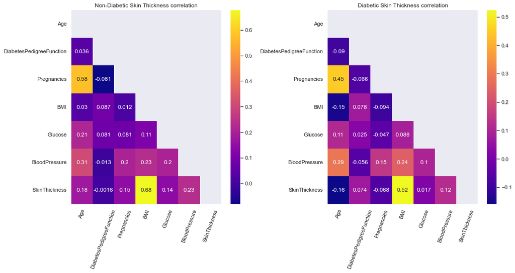

```python
non_diabetic_patient= diab_1[(diab_1['Outcome']==0)]
diabetic_patient= diab_1[(diab_1['Outcome']==1)]

fig, axes = plt.subplots(1, 2, figsize=(15, 8))

# Non-diabetic SkinThickness correlation
compar_data_non_diab= non_diabetic_patient[['Age', 'DiabetesPedigreeFunction','Pregnancies','BMI','Glucose','BloodPressure',
                                            'SkinThickness']]
triang_non_diab = np.triu(np.ones_like(compar_data_non_diab.corr()))
sns.heatmap(compar_data_non_diab.corr(), mask= triang_non_diab, annot=True ,cmap = 'plasma', ax=axes[0])
axes[0].tick_params(axis='x', rotation=70)
axes[0].tick_params(axis='y', rotation=0)
axes[0].title.set_text("Non-Diabetic Skin Thickness correlation")

# Diabetic SkinThickness correlation
compar_data_diab= diabetic_patient[['Age', 'DiabetesPedigreeFunction','Pregnancies','BMI','Glucose','BloodPressure',
                                    'SkinThickness']]
triang_diab = np.triu(np.ones_like(compar_data_diab.corr()))
sns.heatmap(compar_data_diab.corr(), mask= triang_diab, annot=True ,cmap = 'plasma', ax=axes[1])
axes[1].tick_params(axis='x', rotation=70)
axes[1].tick_params(axis='y', rotation=0)
axes[1].title.set_text("Diabetic Skin Thickness correlation")

fig.tight_layout()
sns.set_theme()
plt.show()
```

The correlation of `SkinThickness` and `BMI` is higher for both diabetic and non-diabetic patients.  
Let's check `BMI` min and max:

```python
print("BMI min:", diab_1['BMI'].min())
print("BMI max:", diab_1['BMI'].max())
```

```
BMI min: 18.2
BMI max: 50.0
```

Let's create `BMI` bins: "underweight" 15-20, "normalweight" 20-25, "overweight" 25-30 and "obesity" 30-70

```python
bins_bmi_1 = [15, 19, 24, 29 ,70]
cats_bmi_1 = pd.cut(diab_1['BMI'], bins_bmi_1, labels=["underweight","normalweight", "overweight","obesity"])
diab_1['BMIcats']= cats_bmi_1

# Change NaN values of SkinThickness by "underweight"
underweight_cat= diab_1[diab_1['BMIcats']=="underweight"]
# Non-diabetic
underweight_non_diab= underweight_cat[underweight_cat['Outcome']==0]
underweight_non_diab_val=int(underweight_non_diab['SkinThickness'].mean(skipna=True))
diab_1['SkinThickness'] = np.where((diab_1['SkinThickness'].isnull()) & (diab_1['BMIcats'] == "underweight") &
                                   (diab_1['Outcome'] == 0), underweight_non_diab_val, diab_1['SkinThickness'])
# Diabetic - There are no underweight diabetic
#underweight_diab= underweight_cat[underweight_cat['Outcome']==1]
#underweight_diab_val=int(underweight_diab['SkinThickness'].mean(skipna=True))
#diab_1['SkinThickness'] = np.where((diab_1['SkinThickness'].isnull()) & (diab_1['BMIcats'] == "underweight") &
#                                   (diab_1['Outcome'] == 1), underweight_diab_val, diab_1['SkinThickness'])

# Change NaN values of SkinThickness by "normalweight" score
normalweight_cat= diab_1[diab_1['BMIcats']=="normalweight"]
# Non-diabetic
normalweight_non_diab= normalweight_cat[normalweight_cat['Outcome']==0]
normalweight_non_diab_val=int(normalweight_non_diab['SkinThickness'].mean(skipna=True))
diab_1['SkinThickness'] = np.where((diab_1['SkinThickness'].isnull()) & (diab_1['BMIcats'] == "normalweight") &
                                   (diab_1['Outcome'] == 0), normalweight_non_diab_val, diab_1['SkinThickness'])
# Diabetic
normalweight_diab= normalweight_cat[normalweight_cat['Outcome']==1]
normalweight_diab_val=int(normalweight_diab['SkinThickness'].mean(skipna=True))
diab_1['SkinThickness'] = np.where((diab_1['SkinThickness'].isnull()) & (diab_1['BMIcats'] == "normalweight") &
                                   (diab_1['Outcome'] == 1), normalweight_diab_val, diab_1['SkinThickness'])

# Change NaN values of SkinThickness by "overweight" score
overweight_cat= diab_1[diab_1['BMIcats']=="overweight"]
# Non-diabetic
overweight_non_diab= overweight_cat[overweight_cat['Outcome']==0]
overweight_non_diab_val=int(overweight_non_diab['SkinThickness'].mean(skipna=True))
diab_1['SkinThickness'] = np.where((diab_1['SkinThickness'].isnull()) & (diab_1['BMIcats'] == "overweight") &
                                   (diab_1['Outcome'] == 0), overweight_non_diab_val, diab_1['SkinThickness'])
# Diabetic
overweight_diab= overweight_cat[overweight_cat['Outcome']==1]
overweight_diab_val=int(overweight_diab['SkinThickness'].mean(skipna=True))
diab_1['SkinThickness'] = np.where((diab_1['SkinThickness'].isnull()) & (diab_1['BMIcats'] == "overweight") &
                                   (diab_1['Outcome'] == 1), overweight_diab_val, diab_1['SkinThickness'])

# Change NaN values of SkinThickness by "obesity" score
obesity_cat= diab_1[diab_1['BMIcats']=="obesity"]
# Non-diabetic
obesity_non_diab= obesity_cat[obesity_cat['Outcome']==0]
obesity_non_diab_val=int(obesity_non_diab['SkinThickness'].mean(skipna=True))
diab_1['SkinThickness'] = np.where((diab_1['SkinThickness'].isnull()) & (diab_1['BMIcats'] == "obesity") &
                                   (diab_1['Outcome'] == 0), obesity_non_diab_val, diab_1['SkinThickness'])
# Non-diabetic
obesity_diab= obesity_cat[obesity_cat['Outcome']==1]
obesity_diab_val=int(obesity_diab['SkinThickness'].mean(skipna=True))
diab_1['SkinThickness'] = np.where((diab_1['SkinThickness'].isnull()) & (diab_1['BMIcats'] == "obesity") &
                                   (diab_1['Outcome'] == 1), obesity_diab_val, diab_1['SkinThickness'])

print(diab_1[missing_val].isnull().sum())
```

```
Glucose            0
BloodPressure      0
SkinThickness      0
Insulin          390
BMI                0
dtype: int64
```

Missing values of `SkinThickness` handeled, last is `Insulin` relation among the variables without the missing value:

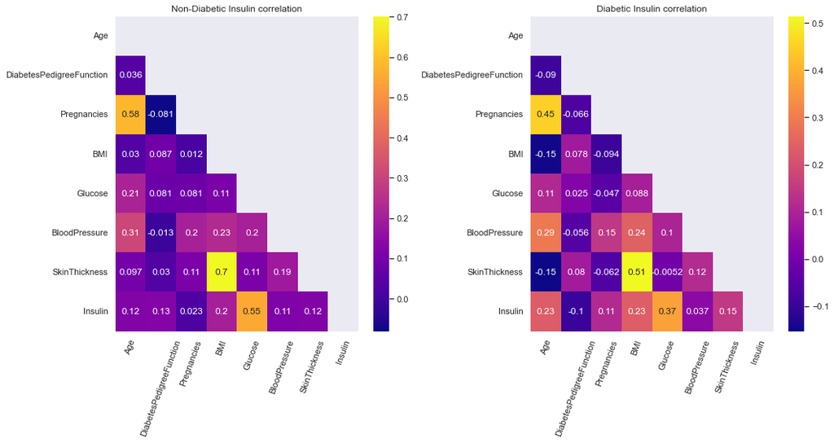

```python
non_diabetic_patient= diab_1[(diab_1['Outcome']==0)]
diabetic_patient= diab_1[(diab_1['Outcome']==1)]

fig, axes = plt.subplots(1, 2, figsize=(15, 8))

# Non-diabetic Insulin correlation
compar_data_non_diab= non_diabetic_patient[['Age', 'DiabetesPedigreeFunction','Pregnancies','BMI','Glucose','BloodPressure',
                                            'SkinThickness','Insulin']]
triang_non_diab = np.triu(np.ones_like(compar_data_non_diab.corr()))
sns.heatmap(compar_data_non_diab.corr(), mask= triang_non_diab, annot=True ,cmap = 'plasma', ax=axes[0])
axes[0].tick_params(axis='x', rotation=70)
axes[0].tick_params(axis='y', rotation=0)
axes[0].title.set_text("Non-Diabetic Insulin correlation")

# Diabetic Insulin correlation
compar_data_diab= diabetic_patient[['Age', 'DiabetesPedigreeFunction','Pregnancies','BMI','Glucose','BloodPressure',
                                    'SkinThickness','Insulin']]
triang_diab = np.triu(np.ones_like(compar_data_diab.corr()))
sns.heatmap(compar_data_diab.corr(), mask= triang_diab, annot=True ,cmap = 'plasma', ax=axes[1])
axes[1].tick_params(axis='x', rotation=70)
axes[1].tick_params(axis='y', rotation=0)
axes[1].title.set_text("Diabetic Insulin correlation")

fig.tight_layout()
sns.set_theme()
plt.show()
```

The correlation of `Insulin` and `Glucose` is higher for both diabetic and non-diabetic patients.  
Bins: "beneath norm" 40-70, "norm" 70-100, "above norm" 100-130, "anomalous" 130-165 and "risk" 165-200

```python
# Bins and categories already exist
# Change NaN values of Insulin by "beneath norm"
beneath_norm_ins_cat= diab_1[diab_1['GlucoseCats']=="beneath norm"]
# Non-diabetic
beneath_norm_ins_non_diab= beneath_norm_ins_cat[beneath_norm_ins_cat['Outcome']==0]
beneath_norm_ins_non_diab_val=int(beneath_norm_ins_non_diab['Insulin'].mean(skipna=True))
diab_1['Insulin'] = np.where((diab_1['Insulin'].isnull()) & (diab_1['GlucoseCats'] == "beneath norm") &
                             (diab_1['Outcome'] == 0), beneath_norm_ins_non_diab_val, diab_1['Insulin'])
# Diabetic - There are no beneath norm diabetic
#beneath_norm_ins_diab= beneath_norm_ins_cat[beneath_norm_ins_cat['Outcome']==1]
#beneath_norm_ins_diab_val=int(beneath_norm_ins_diab['Insulin'].mean(skipna=True))
#diab_1['Insulin'] = np.where((diab_1['Insulin'].isnull()) & (diab_1['GlucoseCats'] == "beneath norm") &
#                             (diab_1['Outcome'] == 1), beneath_norm_ins_diab_val, diab_1['Insulin'])

# Change NaN values of Insulin by "norm" score
norm_ins_cat= diab_1[diab_1['GlucoseCats']=="norm"]
# Non-diabetic
norm_ins_non_diab= norm_ins_cat[norm_ins_cat['Outcome']==0]
norm_ins_non_diab_val=int(norm_ins_non_diab['Insulin'].mean(skipna=True))
diab_1['Insulin'] = np.where((diab_1['Insulin'].isnull()) & (diab_1['GlucoseCats'] == "norm") & (diab_1['Outcome'] == 0),
                             norm_ins_non_diab_val, diab_1['Insulin'])
# Diabetic
norm_ins_diab= norm_ins_cat[norm_ins_cat['Outcome']==1]
norm_ins_diab_val=int(norm_ins_diab['Insulin'].mean(skipna=True))
diab_1['Insulin'] = np.where((diab_1['Insulin'].isnull()) & (diab_1['GlucoseCats'] == "norm") & (diab_1['Outcome'] == 1),
                             norm_ins_diab_val, diab_1['Insulin'])

# Change NaN values of Insulin by "above norm" score
above_norm_ins_cat= diab_1[diab_1['GlucoseCats']=="above norm"]
# Non-diabetic
above_norm_ins_non_diab= above_norm_ins_cat[above_norm_ins_cat['Outcome']==0]
above_norm_ins_non_diab_val=int(above_norm_ins_non_diab['Insulin'].mean(skipna=True))
diab_1['Insulin'] = np.where((diab_1['Insulin'].isnull()) & (diab_1['GlucoseCats'] == "above norm") & (diab_1['Outcome'] == 0),
                             above_norm_ins_non_diab_val, diab_1['Insulin'])
# Diabetic
above_norm_ins_diab= above_norm_ins_cat[above_norm_ins_cat['Outcome']==1]
above_norm_ins_diab_val=int(above_norm_ins_diab['Insulin'].mean(skipna=True))
diab_1['Insulin'] = np.where((diab_1['Insulin'].isnull()) & (diab_1['GlucoseCats'] == "above norm") & (diab_1['Outcome'] == 1),
                             above_norm_ins_diab_val, diab_1['Insulin'])

# Change NaN values of Insulin by "anomalous" score
anomalous_ins_cat= diab_1[diab_1['GlucoseCats']=="anomalous"]
# Non-diabetic
anomalous_ins_non_diab= anomalous_ins_cat[anomalous_ins_cat['Outcome']==0]
anomalous_ins_non_diab_val=int(anomalous_ins_non_diab['Insulin'].mean(skipna=True))
diab_1['Insulin'] = np.where((diab_1['Insulin'].isnull()) & (diab_1['GlucoseCats'] == "anomalous") & (diab_1['Outcome'] == 0),
                             anomalous_ins_non_diab_val, diab_1['Insulin'])
# Diabetic
anomalous_ins_diab= anomalous_ins_cat[anomalous_ins_cat['Outcome']==1]
anomalous_ins_diab_val=int(anomalous_ins_diab['Insulin'].mean(skipna=True))
diab_1['Insulin'] = np.where((diab_1['Insulin'].isnull()) & (diab_1['GlucoseCats'] == "anomalous") & (diab_1['Outcome'] == 1),
                             anomalous_ins_diab_val, diab_1['Insulin'])

# Change NaN values of Insulin by "risk" score
risk_ins_cat= diab_1[diab_1['GlucoseCats']=="risk"]
# Non-diabetic
risk_ins_non_diab= risk_ins_cat[risk_ins_cat['Outcome']==0]
risk_ins_non_diab_val=int(risk_ins_non_diab['Insulin'].mean(skipna=True))
diab_1['Insulin'] = np.where((diab_1['Insulin'].isnull()) & (diab_1['GlucoseCats'] == "risk") & (diab_1['Outcome'] == 0),
                             risk_ins_non_diab_val, diab_1['Insulin'])
# Diabetic
risk_ins_diab= risk_ins_cat[risk_ins_cat['Outcome']==1]
risk_ins_diab_val=int(risk_ins_diab['Insulin'].mean(skipna=True))
diab_1['Insulin'] = np.where((diab_1['Insulin'].isnull()) & (diab_1['GlucoseCats'] == "risk") & (diab_1['Outcome'] == 1),
                             risk_ins_diab_val, diab_1['Insulin'])

print(diab_1[missing_val].isnull().sum())
```

```
Glucose          0
BloodPressure    0
SkinThickness    0
Insulin          0
BMI              0
dtype: int64
```

Now all missing values are filled !

Let's move to distribution method of filling missing values:

### 2. Distribution

First, let's try to guess how every variable distribut:

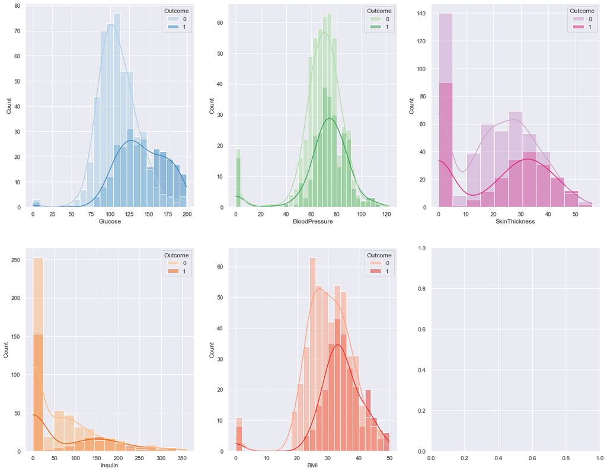

```python
# First, replace NaN with 0 for plot
diabetes[['Glucose','BloodPressure','SkinThickness','Insulin','BMI']] = diabetes[['Glucose','BloodPressure','SkinThickness',
                                                                                  'Insulin','BMI']].replace(np.NaN,0)

diab_rows= diabetes.copy()
fig, axes = plt.subplots(2, 3, figsize=(20,16))

sns.histplot(ax=axes[0,0], data=diab_rows, x='Glucose', hue='Outcome', kde=True, palette= "Blues")
sns.histplot(ax=axes[0,1], data=diab_rows, x='BloodPressure', hue='Outcome', kde=True, palette= "Greens")
sns.histplot(ax=axes[0,2], data=diab_rows, x='SkinThickness', hue='Outcome', kde=True, palette= "PuRd")
sns.histplot(ax=axes[1,0], data=diab_rows, x='Insulin', hue='Outcome', kde=True, palette= "Oranges")
sns.histplot(ax=axes[1,1], data=diab_rows, x='BMI', hue='Outcome', kde=True, palette= "Reds")

sns.set_theme()
plt.show()
```

Seems `Glucose`, `BloodPressure` and `BMI` have Normal Distribution, Let's try to fit Normal probability distribution to every one of these variable with separating non-diabetic patients and diabetic patients:

[figure not shown]

```python
non_diabetic= diab_rows[(diab_rows['Outcome']==0)]
diabetic= diab_rows[(diab_rows['Outcome']==1)]

# Non diabetic glucose
[nd_gluc_mean, nd_gluc_std]= st.norm.fit(non_diabetic['Glucose'])
nd_gluc_x= np.linspace(np.min(non_diabetic['Glucose']), np.max(non_diabetic['Glucose']))
# Diabetic glucose
[d_gluc_mean, d_gluc_std]= st.norm.fit(diabetic['Glucose'])
d_gluc_x= np.linspace(np.min(diabetic['Glucose']), np.max(diabetic['Glucose']))

# Non diabetic blood pressure
[nd_bp_mean, nd_bp_std]= st.norm.fit(non_diabetic['BloodPressure'])
nd_bp_x= np.linspace(np.min(non_diabetic['BloodPressure']), np.max(non_diabetic['BloodPressure']))
# Diabetic blood pressure
[d_bp_mean, d_bp_std]= st.norm.fit(diabetic['BloodPressure'])
d_bp_x= np.linspace(np.min(diabetic['BloodPressure']), np.max(diabetic['BloodPressure']))

# Non diabetic BMI
[nd_bmi_mean, nd_bmi_std]= st.norm.fit(non_diabetic['BMI'])
nd_bmi_x= np.linspace(np.min(non_diabetic['BMI']), np.max(non_diabetic['BMI']))
# Diabetic BMI
[d_bmi_mean, d_bmi_std]= st.norm.fit(diabetic['BMI'])
d_bmi_x= np.linspace(np.min(diabetic['BMI']), np.max(diabetic['BMI']))

fig, axes = plt.subplots(2, 3, figsize=(20,10))

# Fit Normal Distribution on Glucose for diabetic
sns.kdeplot(ax=axes[0,0], data=non_diabetic, x='Glucose', color='g')
axes[0,0].plot(nd_gluc_x, st.norm.pdf(nd_gluc_x, nd_gluc_mean, nd_gluc_std), color='k',)
axes[0,0].legend(["Diab Glucose", "Diab GlucDens"])
# Fit Normal Distribution on Glucose for non-diabetic
sns.kdeplot(ax=axes[1,0], data=diabetic, x='Glucose', color='hotpink')
axes[1,0].plot(d_gluc_x, st.norm.pdf(d_gluc_x, d_gluc_mean, d_gluc_std), color='k',)
axes[1,0].legend(["nonDiab Glucose", "nonDiab GlucDens"])

# Fit Normal Distribution on BloodPressure for diabetic
sns.kdeplot(ax=axes[0,1], data=non_diabetic, x='BloodPressure',color='g')
axes[0,1].plot(nd_bp_x, st.norm.pdf(nd_bp_x, nd_bp_mean, nd_bp_std), color='k',)
axes[0,1].legend(["Diab BP", "Diab BPdens"])
# Fit Normal Distribution on BloodPressure for non-diabetic
sns.kdeplot(ax=axes[1,1], data=diabetic, x='BloodPressure',color='hotpink')
axes[1,1].plot(d_bp_x, st.norm.pdf(d_bp_x, d_bp_mean, d_bp_std), color='k',)
axes[1,1].legend(["nonDiab BP", "nonDiab BPdens"])

# Fit Normal Distribution on BMI for diabetic
sns.kdeplot(ax=axes[0,2], data=non_diabetic, x='BMI',color='g')
axes[0,2].plot(nd_bmi_x, st.norm.pdf(nd_bmi_x, nd_bmi_mean, nd_bmi_std), color='k',)
axes[0,2].legend(["Diab BMI", "Diab BMIdens"])
# Fit Normal Distribution on BMI for non-diabetic
sns.kdeplot(ax=axes[1,2], data=diabetic, x='BMI',color='hotpink')
axes[1,2].plot(d_bmi_x, st.norm.pdf(d_bmi_x, d_bmi_mean, d_bmi_std), color='k',)
axes[1,2].legend(["nonDiab BMI", "nonDiab BMIdens"])

sns.set_theme()
fig.tight_layout()
plt.show()
```

At most cases it seems that the Normal Distribution fits correctly.  
For `SkinThickness` and `Insulin`, the assumption is that without 0's they have Normal Distribution:

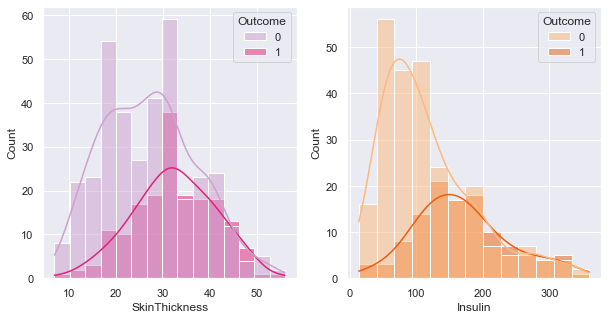

```python
# First, replace 0's with NaN for plot
diabetes[['SkinThickness','Insulin']] = diabetes[['SkinThickness','Insulin']].replace(0,np.NaN)

diab_rows= diabetes.copy()
fig, axes = plt.subplots(1, 2, figsize=(10,5))

sns.histplot(ax=axes[0], data=diab_rows, x='SkinThickness', hue='Outcome', kde=True, palette= "PuRd")
sns.histplot(ax=axes[1], data=diab_rows, x='Insulin', hue='Outcome', kde=True, palette= "Oranges")

sns.set_theme()
plt.show()
```

Therefore, the 0's of `Glucose`, `BloodPressure` and `BMI` (that seems to have Normal Distribution) will be replaced by their **mean**.  
The 0's of `SkinThickness` and `Insulin` (that seems to have Normal Distribution if they had no 0's) will be replaced by their **median**:

```python
# First, replace 0's with NaN for convenience
diab_rows[['Glucose','BloodPressure','BMI','Insulin']] = diab_rows[['Glucose','BloodPressure','BMI',
                                                                    'Insulin']].replace(0,np.NaN)
# Replace NaN with 0 for convenience
diab_rows['SkinThickness'] = diab_rows['SkinThickness'].replace(np.NaN,0)

diab_2=diab_rows.copy()

# Mean value
# Non-diabetic Glucose
gluc_non_diab= diab_2[diab_2['Outcome']==0]
gluc_non_diab_val=int(gluc_non_diab['Glucose'].mean(skipna=True))
diab_2['Glucose'] = np.where((diab_2['Glucose'].isnull()) & (diab_2['Outcome'] == 0), gluc_non_diab_val, diab_2['Glucose'])
# Diabetic Glucose
gluc_diab= diab_2[diab_2['Outcome']==1]
gluc_diab_val=int(gluc_diab['Glucose'].mean(skipna=True))
diab_2['Glucose'] = np.where((diab_2['Glucose'].isnull()) & (diab_2['Outcome'] == 1), gluc_diab_val, diab_2['Glucose'])

# Non-diabetic BloodPressure
bp_non_diab= diab_2[diab_2['Outcome']==0]
bp_non_diab_val=int(bp_non_diab['BloodPressure'].mean(skipna=True))
diab_2['BloodPressure'] = np.where((diab_2['BloodPressure'].isnull()) & (diab_2['Outcome'] == 0), bp_non_diab_val,
                                   diab_2['BloodPressure'])
# Diabetic BloodPressure
bp_diab= diab_2[diab_2['Outcome']==1]
bp_diab_val=int(bp_diab['BloodPressure'].mean(skipna=True))
diab_2['BloodPressure'] = np.where((diab_2['BloodPressure'].isnull()) & (diab_2['Outcome'] == 1), bp_diab_val,
                                   diab_2['BloodPressure'])

# Non-diabetic BMI
bmi_non_diab= diab_2[diab_2['Outcome']==0]
bmi_non_diab_val=bmi_non_diab['BMI'].mean(skipna=True)
diab_2['BMI'] = np.where((diab_2['BMI'].isnull()) & (diab_2['Outcome'] == 0), bmi_non_diab_val, diab_2['BMI'])
# Diabetic BMI
bmi_diab= diab_2[diab_2['Outcome']==1]
bmi_diab_val=bmi_diab['BMI'].mean(skipna=True)
diab_2['BMI'] = np.where((diab_2['BMI'].isnull()) & (diab_2['Outcome'] == 1), bmi_diab_val, diab_2['BMI'])

# Median value
# Non-diabetic SkinThickness
st_non_diab= diab_2[diab_2['Outcome']==0]
st_non_diab_val=int(st_non_diab['SkinThickness'].median())
diab_2['SkinThickness'] = np.where((diab_2['SkinThickness']==0) & (diab_2['Outcome'] == 0), st_non_diab_val,
                                   diab_2['SkinThickness'])
# Diabetic SkinThickness
st_diab= diab_2[diab_2['Outcome']==1]
st_diab_val=int(st_diab['SkinThickness'].median())
diab_2['SkinThickness'] = np.where((diab_2['SkinThickness']==0) & (diab_2['Outcome'] == 1), st_diab_val,
                                   diab_2['SkinThickness'])

# Non-diabetic Insulin
ins_non_diab= diab_2[diab_2['Outcome']==0]
ins_non_diab_val=int(ins_non_diab['Insulin'].median(skipna=True))
diab_2['Insulin'] = np.where((diab_2['Insulin'].isnull()) & (diab_2['Outcome'] == 0), ins_non_diab_val,
                             diab_2['Insulin'])
# Diabetic Insulin
ins_diab= diab_2[diab_2['Outcome']==1]
ins_diab_val=int(ins_diab['Insulin'].median(skipna=True))
diab_2['Insulin'] = np.where((diab_2['Insulin'].isnull()) & (diab_2['Outcome'] == 1), ins_diab_val,
                             diab_2['Insulin'])

# Replace 0's with NaN for convenience
diab_2[['Glucose','BloodPressure','SkinThickness','Insulin','BMI']] = diab_2[['Glucose','BloodPressure','SkinThickness',
                                                                              'Insulin','BMI']].replace(0,np.NaN)

print(diab_2[['Glucose','BloodPressure','SkinThickness','Insulin','BMI']].isnull().sum())
```

```
Glucose          0
BloodPressure    0
SkinThickness    0
Insulin          0
BMI              0
dtype: int64
```

Now all missing values are filled according to distribution, let's view distribution after all missing values are filed:

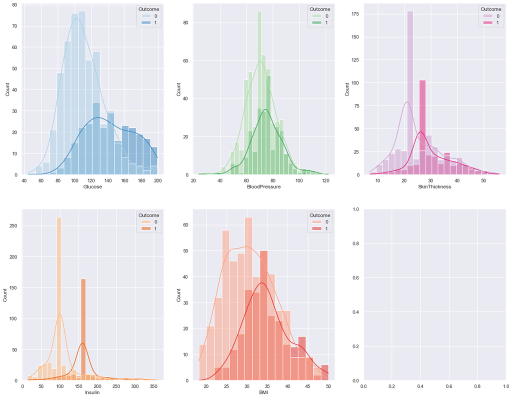

```python
# First, replace NaN with 0 for plot
diab_2[['Glucose','BloodPressure','SkinThickness','Insulin','BMI']] = diab_2[['Glucose','BloodPressure','SkinThickness',
                                                                              'Insulin','BMI']].replace(np.NaN,0)

fig, axes = plt.subplots(2, 3, figsize=(20,16))

sns.histplot(ax=axes[0,0], data=diab_2, x='Glucose', hue='Outcome', kde=True, palette= "Blues")
sns.histplot(ax=axes[0,1], data=diab_2, x='BloodPressure', hue='Outcome', kde=True, palette= "Greens")
sns.histplot(ax=axes[0,2], data=diab_2, x='SkinThickness', hue='Outcome', kde=True, palette= "PuRd")
sns.histplot(ax=axes[1,0], data=diab_2, x='Insulin', hue='Outcome', kde=True, palette= "Oranges")
sns.histplot(ax=axes[1,1], data=diab_2, x='BMI', hue='Outcome', kde=True, palette= "Reds")

sns.set_theme()
plt.show()
```

Now, having `diab_1` and `diab_2` without outliers and missing values, final step:

## Predictive analytics

Data model building, training and testing.

`diabetes` dataset data transformation produced two complete datasets, therefore let's view for every dataset options for predictive analytics:

1. For `diab_1` - The dataset after using correlation & binning
2. For `diab_2` - The dataset after using distribution

Supervised machine learning classification algorithm will be applied for every dataset:

1. KNN classification
2. Logistic Regression
3. Random Forest

First, let's create function to calculate classification algorithm accuracy percentage:

```python
def check_accuracy(pred, test):
    total= test.count()
    compar_col = np.where(pred == test, 1, 0)
    correct= compar_col.sum()
    acc= 100*(correct/total)
    return acc
```

### 1. For `diab_1`

First, let's arrange data into a features matrix & target vector and into train data & test data.

```python
X_1= (diab_1.drop(['Outcome', 'AgeCats', 'GlucoseCats', 'BMIcats'], axis=1)).copy() # features matrix
y_1= diab_1['Outcome'].copy() # target vector
```

Train set would consist 70% of the data and the test set 30% of the data:

```python
# Training data - 70% of data
pre_70_1= int(0.7*diab_1.shape[0])
X_train_1= X_1.head(pre_70_1)
y_train_1= y_1.head(pre_70_1)

# Test data - 30% of data
rem_1= int((diab_1.shape[0])-pre_70_1)
X_test_1= X_1.tail(rem_1)
y_test_1= y_1.tail(rem_1)
```

#### 1.1. KNN - K Nearest Neighbors

To classify a new sample by finding the most common class nearest to its features, therefore let's check odd number of neighbors from 1-10, then accuracy check and view the most accurate:

```python
# Initialize lists for KNN accuracy DataFrame
neighbors_num_1=[]
knn_accuracy_1=[]
knn_preds_1=[] # List of predictions

# Loop for [1, 3, 5, 7, 9] neighbors
for i in range(1, 10, 2):
    knn_clsf= KNeighborsClassifier(i)
    knn_clsf.fit(X_train_1, y_train_1)
    y_pred_knn_1= knn_clsf.predict(X_test_1)
    knn_preds_1.append(y_pred_knn_1)
    acc_knn_1=check_accuracy(y_pred_knn_1, y_test_1) # Check accuracy of i neighbors
    neighbors_num_1.append(i)
    knn_accuracy_1.append(acc_knn_1)

# KNN accuracy DataFrame
knn_dict_1 = {'neighbors number': neighbors_num_1, 'accuracy': knn_accuracy_1}
knn_diab_1  = pd.DataFrame(knn_dict_1)

# Max accuracy
acc_max_1=knn_diab_1['accuracy'].max()
neig_max_1= knn_diab_1[knn_diab_1['accuracy']==acc_max_1]
neig_max_1
```

|  | neighbors number | accuracy |
| --- | --- | --- |
| 3 | 7 | 81.578947 |

It seem that on `diab_1` the max accuracy is about 81% when the number of neighbors is 7.

Since the initial hypothesis connects the prediction with insulin level and the correlation of `Insulin` with `Glucose` is the highest, let's view 7-nearest scatter of `Insulin` with `Glucose` of the test data and the prediction data:

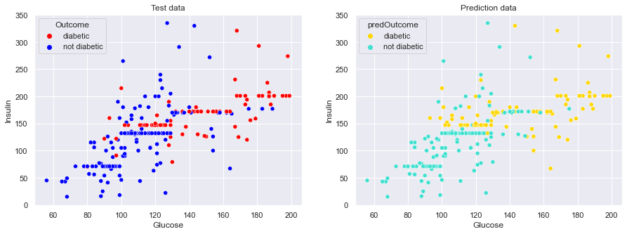

```python
# Test data (with the original classification)
test_data_1= (diab_1.drop(['AgeCats', 'GlucoseCats', 'BMIcats'], axis=1)).copy()
test_data_outcome_1= test_data_1.tail(rem_1).copy()

# Prediction data (with the predicted classification)
pred_data_1= (diab_1.drop(['Outcome','AgeCats', 'GlucoseCats', 'BMIcats'], axis=1)).copy()
knn_pred_data_outcome_1= pred_data_1.tail(rem_1).copy()
y_pred_1_7= knn_preds_1[int((7-1)/2)].copy()
knn_pred_data_outcome_1['predOutcome']=y_pred_1_7

fig, axes = plt.subplots(1, 2, figsize=(15,5))

mapped_test_data_outcome_1= test_data_outcome_1.copy()
mapped_test_data_outcome_1['Outcome'] = mapped_test_data_outcome_1['Outcome'].map({0: "not diabetic", 1: "diabetic"})
sns.scatterplot(ax=axes[0], data=mapped_test_data_outcome_1, x='Glucose', y='Insulin', hue='Outcome',palette=["red", "blue"])
axes[0].title.set_text("Test data")

mapped_knn_pred_data_outcome_1 = knn_pred_data_outcome_1.copy()
mapped_knn_pred_data_outcome_1['predOutcome'] = mapped_knn_pred_data_outcome_1['predOutcome'].map({0: "not diabetic", 1: "diabetic"})
sns.scatterplot(ax=axes[1], data=mapped_knn_pred_data_outcome_1, x='Glucose', y='Insulin', hue='predOutcome',
                palette=["gold", "turquoise"])
axes[1].title.set_text("Prediction data")

sns.set_theme()
plt.show()
```

Now, let's view both scatter of test and prediction together in one figures of non-diabetic and diabetic to notice differences, where there are overlaps it means the prediction compatible with the test:

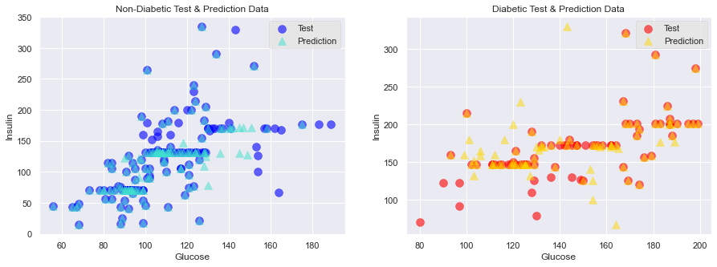

```python
# Non-diabetic test and prediction datas
not_diab_test_data_outcome_1 = test_data_outcome_1[test_data_outcome_1.Outcome != 1]
not_diab_knn_pred_data_outcome_1 = knn_pred_data_outcome_1[knn_pred_data_outcome_1.predOutcome != 1]

# Diabetic test and prediction datas
diab_test_data_outcome_1 = test_data_outcome_1[test_data_outcome_1.Outcome != 0]
diab_knn_pred_data_outcome_1 = knn_pred_data_outcome_1[knn_pred_data_outcome_1.predOutcome != 0]

fig, axes = plt.subplots(1, 2, figsize=(15,5))
plt.style.use('ggplot')

axes[0].scatter(x=not_diab_test_data_outcome_1['Glucose'],y=not_diab_test_data_outcome_1['Insulin'],color='blue',s=100,alpha=0.6,marker='o')
axes[0].scatter(x=not_diab_knn_pred_data_outcome_1['Glucose'],y=not_diab_knn_pred_data_outcome_1['Insulin'],color='turquoise',s=100,alpha=0.5,marker='^')
axes[0].legend(labels=['Test', 'Prediction'])
axes[0].title.set_text("Non-Diabetic Test & Prediction Data")
axes[0].set_xlabel('Glucose')
axes[0].set_ylabel('Insulin')

axes[1].scatter(x=diab_test_data_outcome_1['Glucose'],y=diab_test_data_outcome_1['Insulin'],color='red',s=100,alpha=0.6,marker='o')
axes[1].scatter(x=diab_knn_pred_data_outcome_1['Glucose'],y=diab_knn_pred_data_outcome_1['Insulin'],color='gold',s=100,alpha=0.5,marker='^')
axes[1].legend(labels=['Test', 'Prediction'])
axes[1].title.set_text("Diabetic Test & Prediction Data")
axes[1].set_xlabel('Glucose')
axes[1].set_ylabel('Insulin')

plt.show()
```

For example, on the left scatter plot there are bright blue triangles that are not overlapping a blue circles, that means that there are diabetic samples that classified as non-diabetic.

#### 1.2. Logistic Regression

Predicts the probability of occurrence of a binary target using function of standard logistic distribution.

```python
log_reg = LogisticRegression(max_iter=200)
log_reg.fit(X_train_1, y_train_1)
y_pred_lr_1= log_reg.predict(X_test_1) # Predicted classification
acc_lr_1=check_accuracy(y_pred_lr_1, y_test_1) # Max accuracy
print("The accuracy of Logistic Regression on diab_1 is",round(acc_lr_1),"%")
```

```
The accuracy of Logistic Regression on diab_1 is 79 %
```

Since the initial hypothesis connects the prediction with insulin level, let's view logistic regression line according to `Insulin` of the test data and the prediction data:

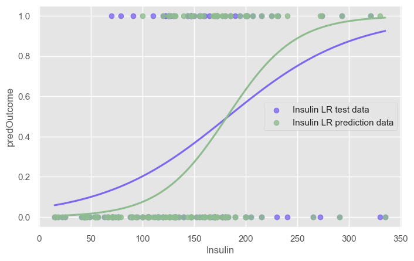

```python
# Prediction data (with the predicted classification)
lr_pred_data_outcome_1= pred_data_1.tail(rem_1).copy()
lr_pred_data_outcome_1['predOutcome']=y_pred_lr_1

plt.figure(figsize=(8,5), dpi=100)

sns.regplot(x='Insulin', y='Outcome', data=test_data_outcome_1, logistic=True, ci=None, label="Insulin LR test data",
            color="mediumslateblue")
sns.regplot(x='Insulin', y='predOutcome', data=lr_pred_data_outcome_1, logistic=True, ci=None,
            label="Insulin LR prediction data",color="darkseagreen")

plt.legend()
sns.set_theme()
plt.show()
```

By the visualization it seems that according to `Insulin` the `LogisticRegression` model shifts `Insulin` values lower at some points and higher at some points, which by the initial hypothesis can change a prediction from diabetic to non-diabetic and vice versa.

#### 1.3. Random Forest

```python
# Initialize lists for Random Forest accuracy DataFrame
estimators_num_1=[]
rf_accuracy_1=[]
rf_preds_1=[] # List of predictions

rng = np.random.RandomState(0) # Random generation

# Loop for [100, 200, 300, 400, 500] trees
for i in range(100, 501, 100):
    rand_forest=RandomForestClassifier(n_estimators=i, random_state=rng, max_depth=8,
                                       min_samples_split= round(0.2*X_train_1.shape[0]))
    rand_forest.fit(X_train_1, y_train_1)
    y_pred_rf_1= rand_forest.predict(X_test_1)
    rf_preds_1.append(y_pred_rf_1)
    acc_rf_1=check_accuracy(y_pred_rf_1, y_test_1) # Check accuracy of i trees
    estimators_num_1.append(i)
    rf_accuracy_1.append(acc_rf_1)

# Random Forest accuracy DataFrame
rf_dict_1 = {'estimators number': estimators_num_1, 'accuracy': rf_accuracy_1}
rf_diab_1  = pd.DataFrame(rf_dict_1)

# Max accuracy
rf_acc_max_1=rf_diab_1['accuracy'].max()
esti_max_1= rf_diab_1[rf_diab_1['accuracy']==rf_acc_max_1]
esti_max_1
```

|  | estimators number | accuracy |
| --- | --- | --- |
| 2 | 300 | 83.333333 |

It seem that on `diab_1` the max accuracy is about 83% and when the estimator number is 300.

Since the tree is probably too large to visualize, let's limit the depth of the tree.  
For the visualization **import** `plot_tree` **from** `sklearn.tree`:

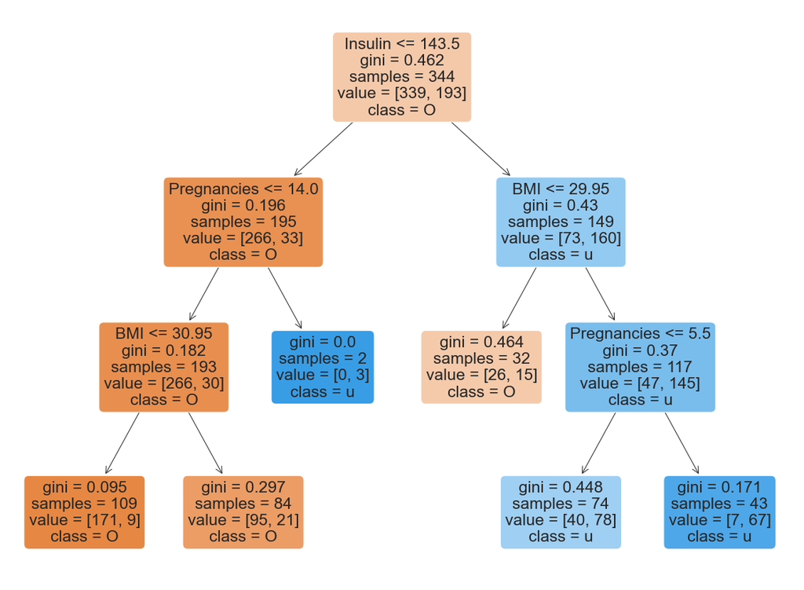

```python
from sklearn.tree import plot_tree

#Diab_1 without categorical variables
origin_diab_1=(diab_1.drop(['AgeCats', 'GlucoseCats', 'BMIcats'], axis=1)).copy()
# Train RandomForest with 300 trees with depth 3
rf = RandomForestClassifier(n_estimators=300, max_depth=3, random_state=rng, min_samples_split= round(0.2*X_train_1.shape[0]))
rf.fit(X_train_1, y_train_1)
fig = plt.figure(figsize=(20, 15))
plot_tree(rf.estimators_[0], feature_names=origin_diab_1.columns, class_names='Outcome',
          filled=True, impurity=True, rounded=True)

plt.show()
```

Let's view subtotal of all classification algorithms accuracy:

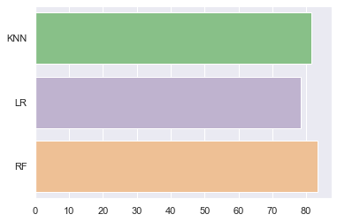

```python
# diab_1 accuracy series
clsf_diab_1={'KNN':neig_max_1['accuracy'].max(), 'LR':acc_lr_1.max(), 'RF':esti_max_1['accuracy'].max()}
clsf_diab_1_ser = pd.Series(data=clsf_diab_1, index=['KNN', 'LR', 'RF'])

sns.barplot(x=clsf_diab_1_ser.values, y=clsf_diab_1_ser.index, palette='Accent')

sns.set_theme()
plt.show()
```

From first look, it seems Random Forest is the most accurate.

Classification and accuracy check for `diab_1` is done, let's move to `diab_2`:

### 2. For `diab_2`

First, let's arrange data into a features matrix & target vector and into train data & test data:

```python
X_2= (diab_2.loc[:, diab_2.columns != 'Outcome']).copy() # features matrix
y_2= diab_2['Outcome'].copy() # target vector

# Training data - 70% of data
pre_70_2= int(0.7*diab_2.shape[0])
X_train_2= X_2.head(pre_70_2)
y_train_2= y_2.head(pre_70_2)

# Test data - 30% of data
rem_2= int((diab_2.shape[0])-pre_70_2)
X_test_2= X_2.tail(rem_2)
y_test_2= y_2.tail(rem_2)
```

#### 2.1. KNN

let's check odd number of neighbors from 1-10, then accuracy check and view the most accurate:

```python
# Initialize lists for KNN accuracy DataFrame
neighbors_num_2=[]
knn_accuracy_2=[]
knn_preds_2=[] # List of predictions

# Loop for [1, 3, 5, 7, 9] neighbors
for i in range(1, 10, 2):
    knn_clsf= KNeighborsClassifier(i)
    knn_clsf.fit(X_train_2, y_train_2)
    y_pred_knn_2= knn_clsf.predict(X_test_2)
    knn_preds_2.append(y_pred_knn_2)
    acc_knn_2=check_accuracy(y_pred_knn_2, y_test_2) # Check accuracy of i neighbors
    neighbors_num_2.append(i)
    knn_accuracy_2.append(acc_knn_2)

# KNN accuracy DataFrame
knn_dict_2 = {'neighbors number': neighbors_num_2, 'accuracy': knn_accuracy_2}
knn_diab_2  = pd.DataFrame(knn_dict_2)

# Max accuracy
acc_max_2=knn_diab_2['accuracy'].max()
neig_max_2= knn_diab_2[knn_diab_2['accuracy']==acc_max_2]
neig_max_2
```

|  | neighbors number | accuracy |
| --- | --- | --- |
| 4 | 9 | 88.311688 |

It seem that on `diab_2` the max accuracy is about 88% and when the number of neighbors is 9.

Since the initial hypothesis connects the prediction with insulin level and the correlation of `Insulin` with `Glucose` is the highest, let's view 9-nearest scatter of `Insulin` with `Glucose` of the test data and the prediction data:

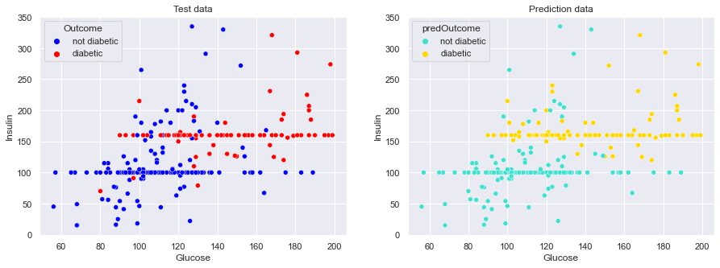

```python
# Test data (with the original classification)
test_data_2= diab_2.copy()
test_data_outcome_2= test_data_2.tail(rem_2).copy()

# Prediction data (with the predicted classification)
pred_data_2= (diab_2.loc[:, diab_2.columns != 'Outcome']).copy()
#pred_data_2= (diab_2.drop(['Outcome'], axis=1)).copy()
knn_pred_data_outcome_2= pred_data_2.tail(rem_2).copy()
y_pred_2_9= knn_preds_2[int((9-1)/2)].copy()
knn_pred_data_outcome_2['predOutcome']=y_pred_2_9

fig, axes = plt.subplots(1, 2, figsize=(15,5))

mapped_test_data_outcome_2= test_data_outcome_2.copy()
mapped_test_data_outcome_2['Outcome'] = mapped_test_data_outcome_2['Outcome'].map({0: "not diabetic", 1: "diabetic"})
sns.scatterplot(ax=axes[0], data=mapped_test_data_outcome_2, x='Glucose', y='Insulin', hue='Outcome',palette=["blue","red"])
axes[0].title.set_text("Test data")

mapped_knn_pred_data_outcome_2 = knn_pred_data_outcome_2.copy()
mapped_knn_pred_data_outcome_2['predOutcome'] = mapped_knn_pred_data_outcome_2['predOutcome'].map({0: "not diabetic", 1: "diabetic"})
sns.scatterplot(ax=axes[1], data=mapped_knn_pred_data_outcome_2, x='Glucose', y='Insulin', hue='predOutcome',
                palette=["turquoise","gold"])
axes[1].title.set_text("Prediction data")

sns.set_theme()
plt.show()
```

Now, let's view both scatter of test and prediction together in one figures of non-diabetic and diabetic to notice differences, where there are overlaps it means the prediction compatible with the test:

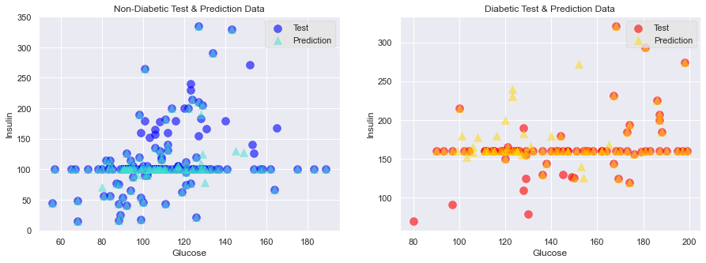

```python
# Non-diabetic test and prediction datas
not_diab_test_data_outcome_2 = test_data_outcome_2[test_data_outcome_2.index.isin(list(test_data_outcome_2.index.values)) & (test_data_outcome_2.Outcome!=1)]
not_diab_knn_pred_data_outcome_2 = knn_pred_data_outcome_2[knn_pred_data_outcome_2.index.isin(list(knn_pred_data_outcome_2.index.values)) & (knn_pred_data_outcome_2.predOutcome != 1)]

# Diabetic test and prediction datas
diab_test_data_outcome_2 = test_data_outcome_2[test_data_outcome_2.index.isin(list(test_data_outcome_2.index.values)) & (test_data_outcome_2.Outcome != 0)]
diab_knn_pred_data_outcome_2 = knn_pred_data_outcome_2[knn_pred_data_outcome_2.index.isin(list(knn_pred_data_outcome_2.index.values)) & (knn_pred_data_outcome_2.predOutcome != 0)]

fig, axes = plt.subplots(1, 2, figsize=(15,5))
plt.style.use('ggplot')

axes[0].scatter(x=not_diab_test_data_outcome_2['Glucose'],y=not_diab_test_data_outcome_2['Insulin'],color='blue',s=100,alpha=0.6,marker='o')
axes[0].scatter(x=not_diab_knn_pred_data_outcome_2['Glucose'],y=not_diab_knn_pred_data_outcome_2['Insulin'],color='turquoise',s=100,alpha=0.5,marker='^')
axes[0].legend(labels=['Test', 'Prediction'])
axes[0].title.set_text("Non-Diabetic Test & Prediction Data")
axes[0].set_xlabel('Glucose')
axes[0].set_ylabel('Insulin')

axes[1].scatter(x=diab_test_data_outcome_2['Glucose'],y=diab_test_data_outcome_2['Insulin'],color='red',s=100,alpha=0.6,marker='o')
axes[1].scatter(x=diab_knn_pred_data_outcome_2['Glucose'],y=diab_knn_pred_data_outcome_2['Insulin'],color='gold',s=100,alpha=0.5,marker='^')
axes[1].legend(labels=['Test', 'Prediction'])
axes[1].title.set_text("Diabetic Test & Prediction Data")
axes[1].set_xlabel('Glucose')
axes[1].set_ylabel('Insulin')

plt.show()
```

For example, on the right scatter plot there are yellow triangles that are not overlapping red circles, that means that there are non-diabetic samples that classified as diabetic.  
Might assume that those mismatches are due to small amount of diabetic samples.

#### 2.2. Logistic Regression

```python
log_reg = LogisticRegression(max_iter=200)
log_reg.fit(X_train_2, y_train_2)
y_pred_lr_2= log_reg.predict(X_test_2)
acc_lr_2=check_accuracy(y_pred_lr_2, y_test_2)
print("The accuracy of Logistic Regression on diab_2 is",round(acc_lr_2),"%")
```

```
The accuracy of Logistic Regression on diab_2 is 82 %
```

Since the initial hypothesis connects the prediction with insulin level, let's view logistic regression line according to `Insulin` of the test data and the prediction data:

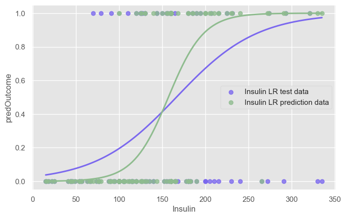

```python
# Prediction data (with the predicted classification)
lr_pred_data_outcome_2= pred_data_2.tail(rem_2).copy()
lr_pred_data_outcome_2['predOutcome']=y_pred_lr_2

plt.figure(figsize=(8,5), dpi=100)

sns.regplot(x='Insulin', y='Outcome', data=test_data_outcome_2, logistic=True, ci=None,
            label="Insulin LR test data", color="mediumslateblue")
sns.regplot(x='Insulin', y='predOutcome', data=lr_pred_data_outcome_2, logistic=True, ci=None,
            label="Insulin LR prediction data",color="darkseagreen")

plt.legend()
sns.set_theme()
plt.show()
```

Same conclusion as `diab_1` - According to `Insulin` the `LogisticRegression` model shifts `Insulin` values lower at some points and higher at some points, which by the initial hypothesis can change a prediction from diabetic to non-diabetic and vice versa.

#### 2.3. RandomForest

```python
# Initialize lists for Random Forest accuracy DataFrame
estimators_num_2=[]
rf_accuracy_2=[]
rf_preds_2=[] # List of predictions

rng = np.random.RandomState(0) # Random generation

# Loop for [100, 200, 300, 400, 500] trees
for i in range(100, 501, 100):
    rand_forest=RandomForestClassifier(n_estimators=i, random_state=rng, max_depth=8,
                                       min_samples_split=round(0.2*X_train_2.shape[0]))
    rand_forest.fit(X_train_2, y_train_2)
    y_pred_rf_2= rand_forest.predict(X_test_2)
    rf_preds_2.append(y_pred_rf_2)
    acc_rf_2=check_accuracy(y_pred_rf_2, y_test_2) # Check accuracy of i trees
    estimators_num_2.append(i)
    rf_accuracy_2.append(acc_rf_2)

# Random Forest accuracy DataFrame
rf_dict_2 = {'estimators number': estimators_num_2, 'accuracy': rf_accuracy_2}
rf_diab_2  = pd.DataFrame(rf_dict_2)

# Max accuracy
rf_acc_max_2=rf_diab_2['accuracy'].max()
esti_max_2= rf_diab_2[rf_diab_2['accuracy']==rf_acc_max_2]
esti_max_2
```

|  | estimators number | accuracy |
| --- | --- | --- |
| 0 | 100 | 90.04329 |

It seem that on `diab_2` the max accuracy is about 90% and when the estimator number is 100.

Since the tree is probably too large to visualize, let's limit the depth of the tree:

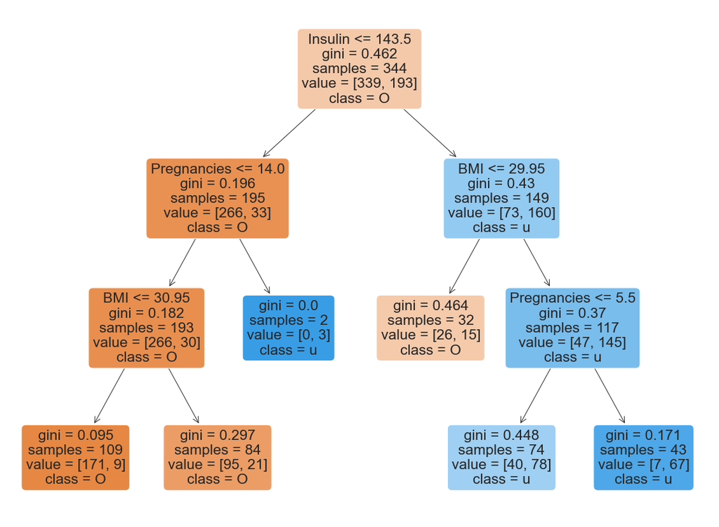

```python
# Train RandomForest with 100 trees with depth 3
rf = RandomForestClassifier(n_estimators=100, max_depth=3, random_state=rng, min_samples_split=round(0.2*X_train_2.shape[0]))
rf.fit(X_train_1, y_train_1)
fig = plt.figure(figsize=(20, 15))
plot_tree(rf.estimators_[0], feature_names=diab_2.columns, class_names='Outcome', filled=True, impurity=True, rounded=True)

plt.show()
```

Let's view subtotal of all classification algorithms accuracy:

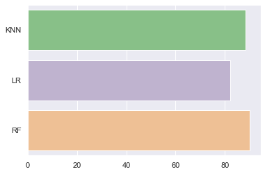

```python
# diab_2 accuracy series
clsf_diab_2={'KNN':neig_max_2['accuracy'].max(), 'LR':acc_lr_2.max(), 'RF':esti_max_2['accuracy'].max()}
clsf_diab_2_ser = pd.Series(data=clsf_diab_2, index=['KNN', 'LR', 'RF'])

sns.barplot(x=clsf_diab_2_ser, y=clsf_diab_2_ser.index, palette='Accent')

sns.set_theme()
plt.show()
```

From first look, it seems Random Forest is the most accurate.

Let's do final summarize:

## Summation

Main results and conclusions.

First, let's view the two datasets with the prediction accuracy:

|  | KNN | LR | RF |
| --- | --- | --- | --- |
| diab_1 | 81.578947 | 78.508772 | 83.333333 |
| diab_2 | 88.311688 | 82.251082 | 90.043290 |

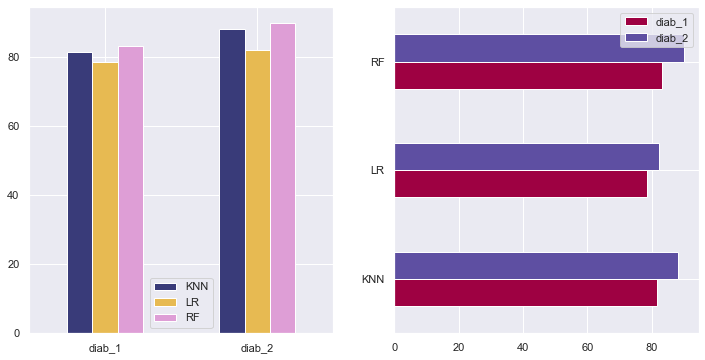

```python
# Summary DataFrame
summary= pd.DataFrame({'diab_1': clsf_diab_1_ser,'diab_2': clsf_diab_2_ser})
display(summary.T)

fig, axes = plt.subplots(1, 2)
summary.T.plot(kind="bar", rot=0, ax=axes[0] , figsize=(12, 6), colormap='tab20b')
summary.plot(kind="barh", ax=axes[1], figsize=(12, 6), colormap='Spectral')

sns.set_theme()
plt.show()
```

The max accuracy of `KnnClassifier` is about 88% and according to `diab_2`  
The max accuracy of `LogisticRegression` is about 82% and according to `diab_2`  
The max accuracy of `RandomForest` is about 90% and according to `diab_2`

By that it seems that `diab_2` is unambiguously the most accurate dataset.

> **Conclusion:** Distribution is more accurate method to fill missing values than correlation and binning.  
> From this conclusion, the answer to the research question about influence of variable on other variable occurs $\Longrightarrow$ Even though there is high correlation between variables, the influence of one on the other is insufficient.

The classification algorithm with the max accuracy for both datasets is `RandomForest`.

> **Conclusion:** In a decision tree there are deep branching and flat branching, this indicates there are variables that more significant to state the prediction, like Insulin from the initial hypothesis $ \Longrightarrow $ This conclusion rise the following **question**: In `diabetes` was great amount of missing values at `Insulin` variable, did it affect the accuracy of `KnnClassifier`algorithm?

In summary, the final project discovered that the preferred method for handling missing values is `distribution` method and the preferred method for classification is `RandomForest` algorithm.

Regarding `RandomForest` it's importent to point out that its accuracy may be devalued if the the min number of samples required at an internal node is higher, while in the project the min was 20% of the samples.

In further research where there will be less missing values on significant variables and where the min number of samples required at an internal node is higher at `RandomForest` algorithm , `KNN` algorithm should take into consideration because it has almost similar high accuracy to `RandomForest` and less running time, therefore would probably be better for diabetes prediction.